# R Notes on Correlation, Association Measures, etc.

## Between 1 CONTINUOUS variable AND 1 CATEGORICAL variable

EXE: Donation amount and ConnectionLevel__c_NA

### a) One-Way ANOVA (F-Test)

ANOVA and One-Way ANOVA F-Test for testing relationships between Numerical and Categorical variables FOLLOWING: http://www.sthda.com/english/wiki/one-way-anova-test-in-r#what-is-one-way-anova-test CHECK also: https://thomasmock.netlify.com/post/a-gentle-guide-to-tidy-statistics-in-r/ CHECK also: https://ademos.people.uic.edu/Chapter20.html

GOAL: for comparing means in a situation where there are more than two groups

$H_0$ : Null Hyp = the means of the different groups are the same $H_1$ : Alternative hyp = At least one sample mean is not equal to the others.

NOTE: + It only looks if **in general** the groups differ (but not specifically by how much and which of them) + Better to have data in long form

```r
# --------One-Way ANOVA F-Test
# Show the levels
levels(AC_ppl_fakeID$ConnectionLevel__c_NA)

aov1 = aov( Acc_Don_NYE2019__c ~ ConnectionLevel__c_NA, data = AC_ppl_fakeID)
summary(aov1) # diff between the groups significant at 0.001

aov2 = aov(Acc_Don_NYE2019__c ~ HasEmail, data = AC_ppl_fakeID )
summary(aov2) # diff between the groups significant at 0.001

aov3 = aov(Acc_Don_NYE2019__c ~ EmLastOpenFactor, data = AC_ppl_fakeID )
summary(aov3)  # diff between the groupsnot sig
```

[output not shown]

### b) Multiple pairwise-comparison between the groups’ means ANOVA

**Tukey multiple pairwise-comparisons** for post-hoc comparison

The function TukeyHD() takes the fitted ANOVA as an argument.

INTERPRETATION: **diff**: difference between means of the two groups **lwr, upr**: the lower and the upper end point of the confidence interval at 95% (default) **p adj**: p-value after adjustment for the multiple comparisons.

```r
# ==== Group by group across ConnectionLevel__c_NA
# aov1 = aov( Acc_Don_NYE2019__c ~ ConnectionLevel__c_NA, data = AC_ppl_fakeID)
TukeyRes <- stats::TukeyHSD(aov1, ordered = F)

# ==== Show table
# OR
# TukeyResTukeyRes[1:1] #
TukeyRes_df <- as.data.frame(TukeyRes$ConnectionLevel__c_NA)

# # ==== Display
caption <- "Pairwise-comparison between the means of groups (ConnectionLevel Types)"
TukeyRes_df_table <- pandoc.table.return(TukeyRes_df,
                                                      keep.line.breaks = TRUE,
                                                      style = "simple",
                                                      justify = "lrrrr",
                                                      caption = caption)
cat(TukeyRes_df_table)
```

[output not shown]

### a) Two-Factor ANOVA (F-Test)

**Show also an interaction.** The beauty of a two factor model is that you can see, not only how factor A affects the mean and factor B affects the mean but the interplay of A and B, specifically to see if the effect of one factor is moderated by the levels of another factor.

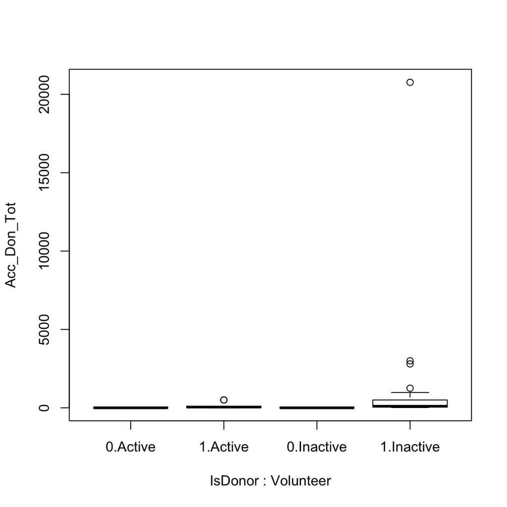

```r
# Comparing means with a two-factor ANOVA

# Get an Idea...
boxplot(Acc_Don_Tot ~ IsDonor*Volunteer, data = AC_ppl_fakeID)
```

```r
# Model with interaction
aov1 <- aov(Acc_Don_Tot ~
            # IsDonor + Volunteer + IsDonor:Volunteer,
            IsDonor*Volunteer,
                data = AC_ppl_fakeID)
summary(aov1)

# Additional information on model
model.tables(aov1)
model.tables(aov1, type = "means")
model.tables(aov1, type = "effects")  # "effects" is default

# Post-hoc test
TukeyHSD(aov1)
```

# COMPARING MEANS

## T-test to compare means of independent groups

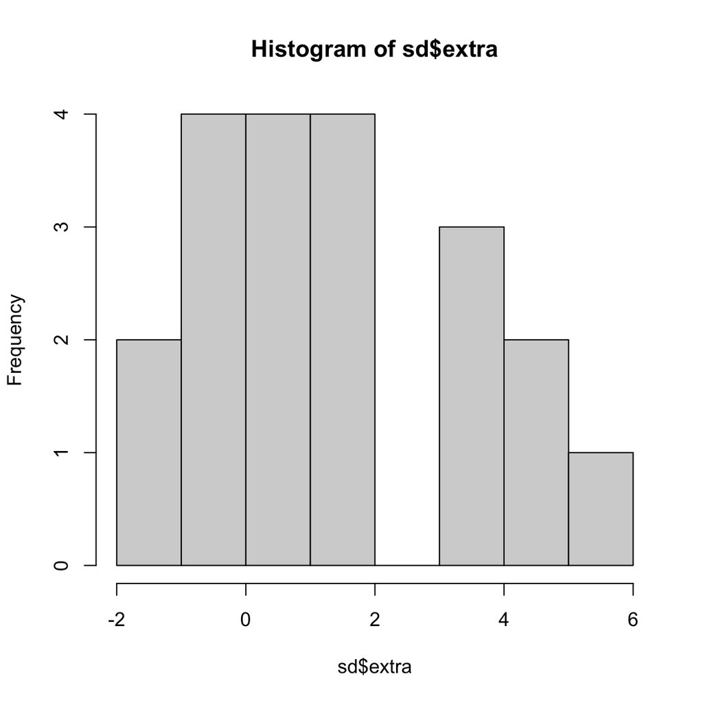

```r
# Comparing means with the t-test

# Load data
# ?sleep
sleep[1:5, ]
sd <- sleep[, 1:2]  # Save just the first two variables
sd[1:5, ]  # Show the first 5 cases

# Some quick plots to check data
hist(sd$extra, col = "lightgray")
```

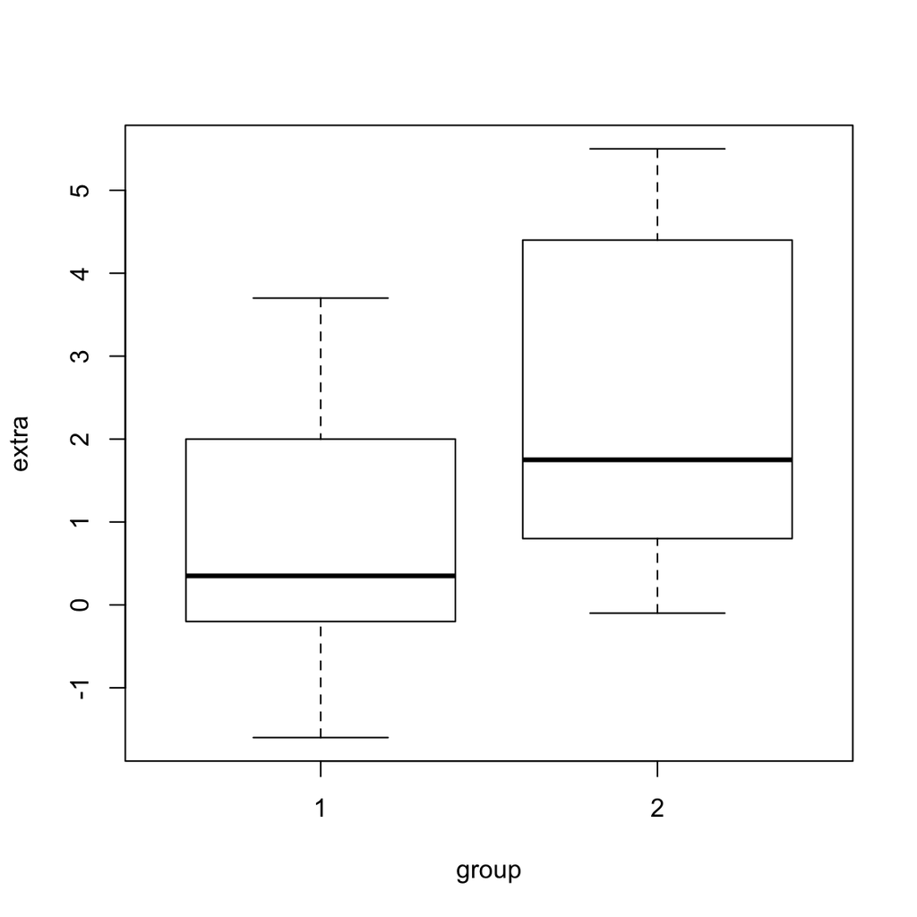

```r
boxplot(extra ~ group, data = sd)
```

```r
# Independent 2-group t-test (with defaults)
t.test(extra ~ group, data = sd)

# t-test with options
t.test(extra ~ group,
       data = sd,
       alternative = "less",  # One-tailed test
       conf.level = 0.80)  # 80% CI (vs. 95%)

# Create two groups of random data in separate variables
# Good because actual difference is known
x <- rnorm(30, mean = 20, sd = 5)
y <- rnorm(30, mean = 22, sd = 5)
t.test(x, y)

# rm(list = ls())  # Clean up
```

## Paired T-test to compare means of paired groups (e.g. same group in t1 and t2)

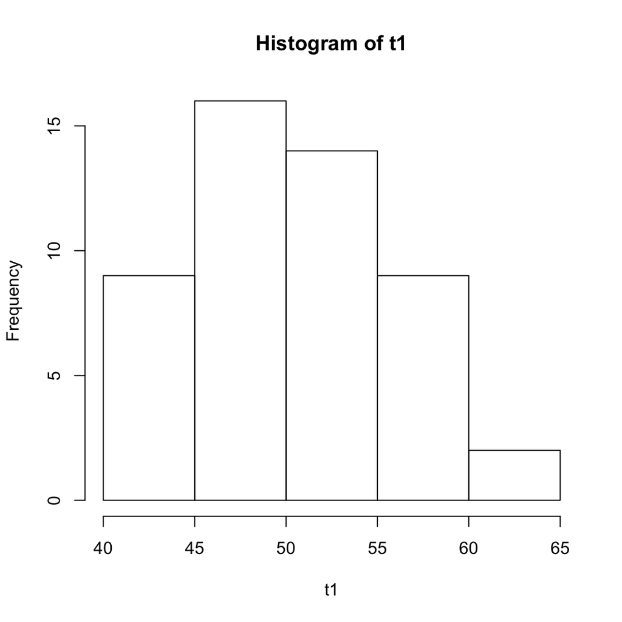

```r
# Load data
# Create random data
t1 <- rnorm(50, mean = 52, sd = 6)  # Time 1
dif <- rnorm(50, mean = 6, sd = 12)  # Difference
t2 <- t1 + dif  # Time 2

# Some quick plots to check data
hist(t1)
```

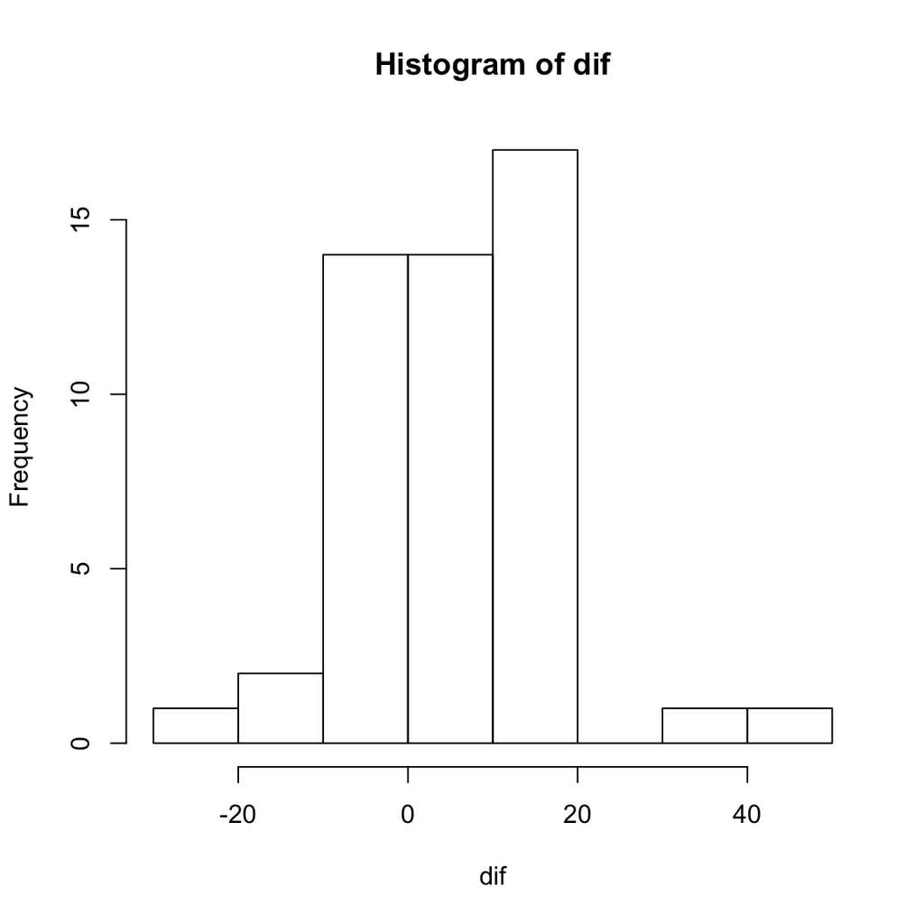

```r
hist(dif)
```

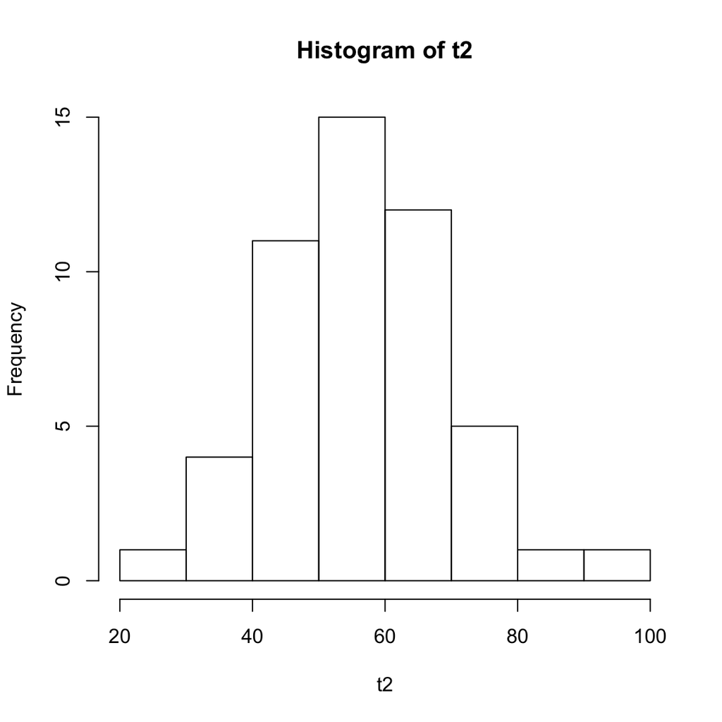

```r
hist(t2)
```

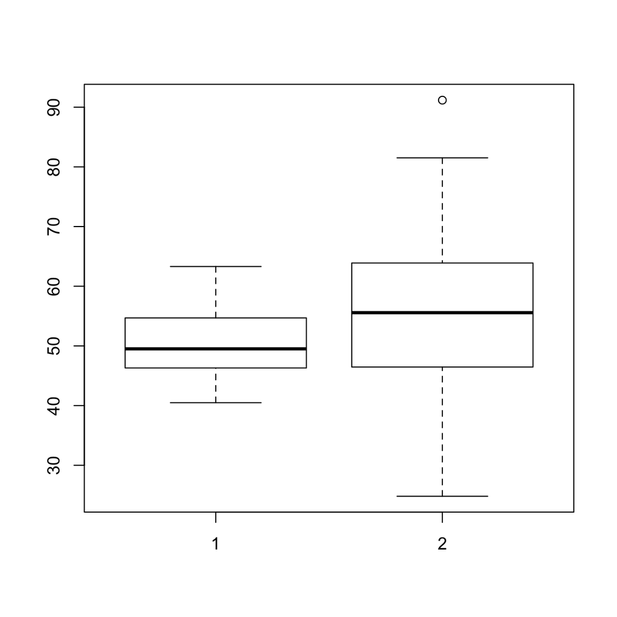

```r
boxplot(t1, t2)
```

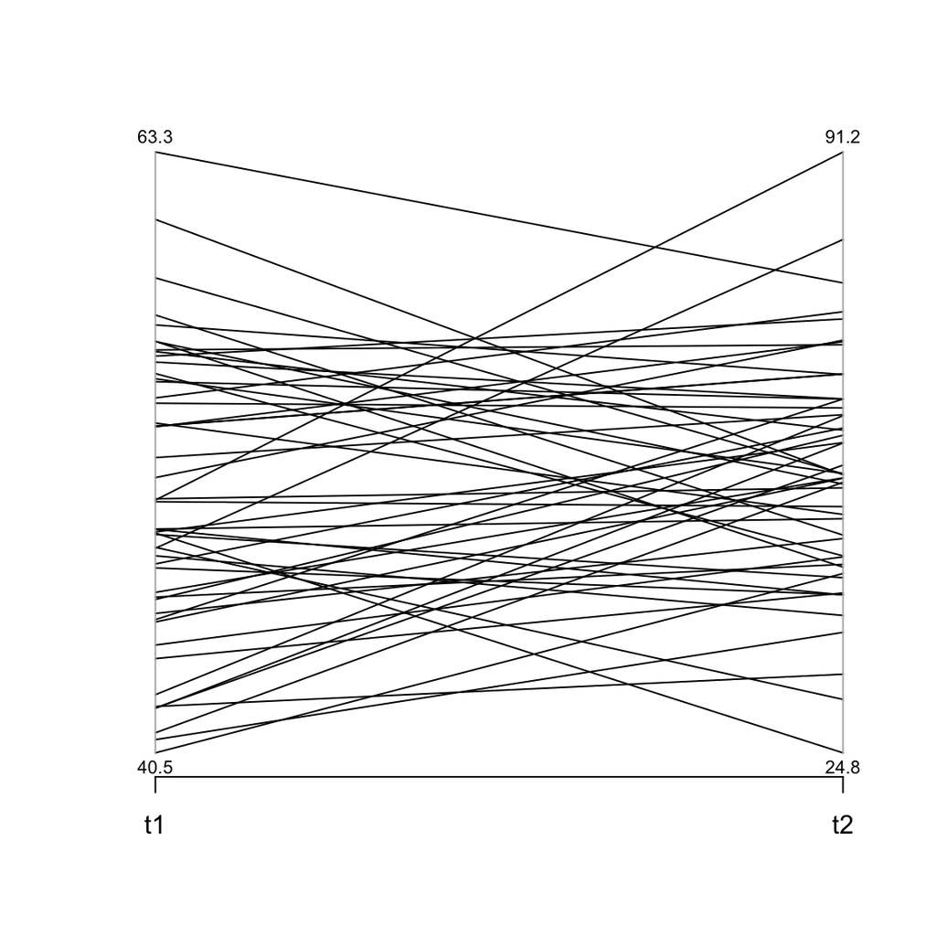

```r
# Save variables in dataframe and use "MASS"
# to create parallel coordinate plot
pairs <- data.frame(t1, t2)
require("MASS")
parcoord(pairs, var.label = TRUE)
```

```r
# Paired t-test (with defaults)
t.test(t2, t1, paired = TRUE)

# Paired t-test with options
t.test(t2, t1,
       paired = TRUE,
       mu = 6,  # Specify non-0 null value
       alternative = "greater",  # One-tailed test
       conf.level = 0.99)  # 99% CI (vs. 95%)

# Clean up
detach("package:MASS", unload=TRUE)
# rm(list = ls())
```

# COMPARING PROPORTIONS

(*) % of success across groups

```r
# Comparing proportions

# Load data
# Need two vectors:
# One specifies the total number of people in each group
# This creates a vector with 5 100s in it, for 5 groups
# Same as "number of trials"
n5 <- c(rep(100, 5))
# Another specifies the number of people who are in category
# Same as "number of successes"
x5 <- c(65, 60, 60, 50, 45)
prop.test(x5, n5)

# If there are only two groups, then it gives a confidence
# interval for the difference between the groups;
# the default CI is .95
n2 <- c(40, 40)  # Number of trials
x2 <- c(30, 20)  # Number of successes
prop.test(x2, n2, conf.level = .80)
```

# CLUSTER ANALISYS

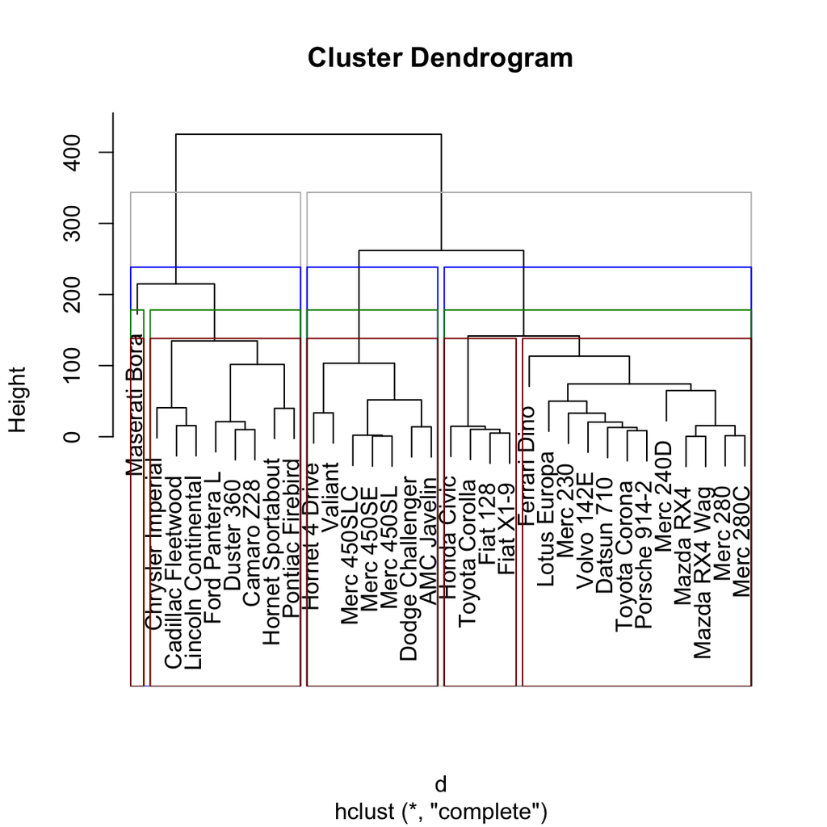

```r
# Conducting a cluster analysis

# Load data
#?mtcars
data(mtcars)
mtcars[1:5, ]
mtcars1 <- mtcars[, c(1:4, 6:7, 9:11)]  # Select variables
mtcars1[1:5, ]

# Three major kinds of clustering:
#   1. Split into set number of clusters (e.g., kmeans)
#   2. Hierarchical: Start separate and combine
#   3. Dividing: Start with a single group and split

# We'll use hierarchical clustering
# Need distance matrix (dissimilarity matrix)
d <- dist(mtcars1)
d  # Huge matrix

# Use distance matrix for clustering
c <- hclust(d)
c

# Plot dendrogram of clusters
plot(c)

# Put observations in groups
# Need to specify either k = groups or h = height
g3 <- cutree(c, k = 3)  # "g3" = "groups 3"
# cutree(hcmt, h = 230) will give same result
g3
# Or do several levels of groups at once
# "gm" = "groups/multiple"
gm <- cutree(c, k = 2:5) # or k = c(2, 4)
gm

# Draw boxes around clusters
rect.hclust(c, k = 2, border = "gray")
rect.hclust(c, k = 3, border = "blue")
rect.hclust(c, k = 4, border = "green4")
rect.hclust(c, k = 5, border = "darkred")
```

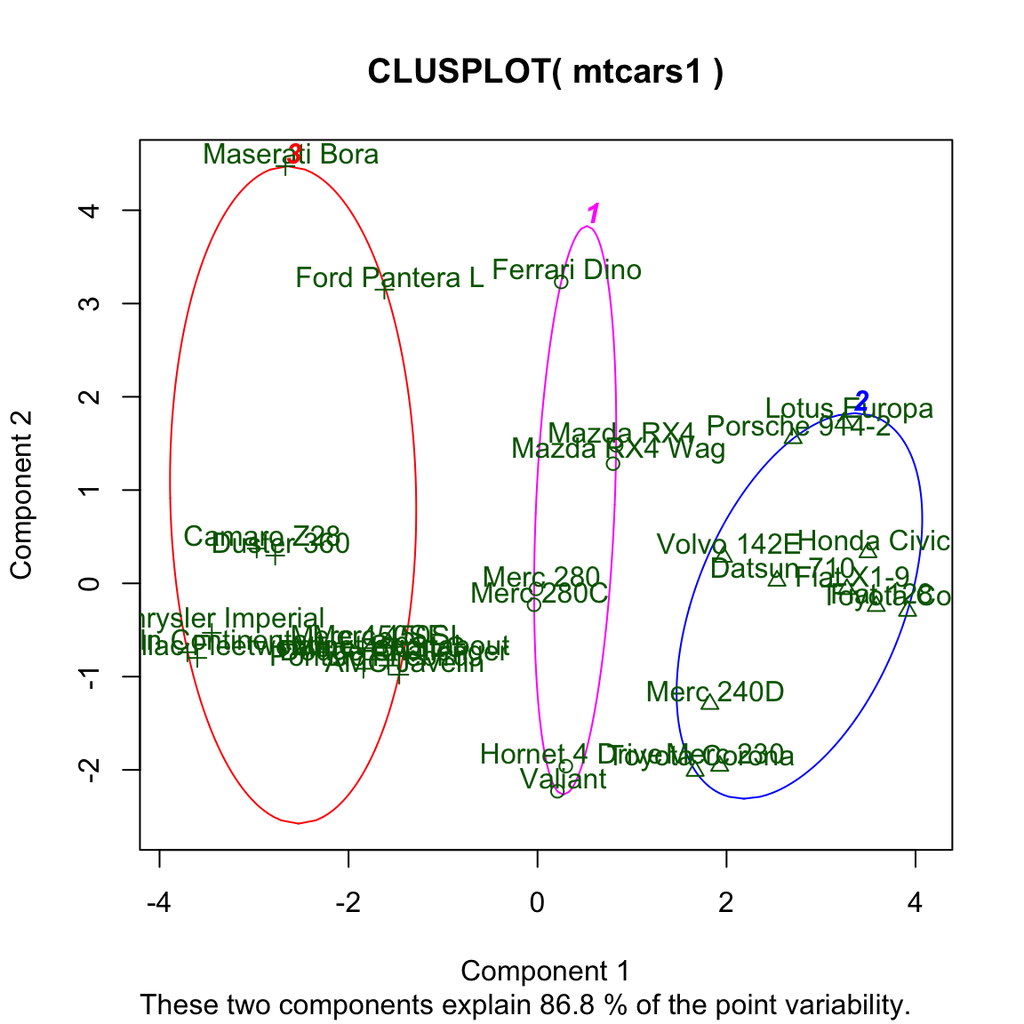

```r
# k-means clustering
km <- kmeans(mtcars1, 3)
km

# Graph based on k-means
require(cluster)
clusplot(mtcars1,  # data frame
         km$cluster,  # cluster data
         color = TRUE,  # color
#          shade = TRUE,  # Lines in clusters
         lines = 3,  # Lines connecting centroids
         labels = 2)  # Labels clusters and cases
```

# PRINCIPAL COMPONENT ANALISYS

From “psych” package documentation (p. 213) *“The primary empirical difference between a components versus a factor model is the treatment of the variances for each item. Philosophically, components are weighted composites of observed variables while in the factor model, variables are weighted composites of the factors.”*

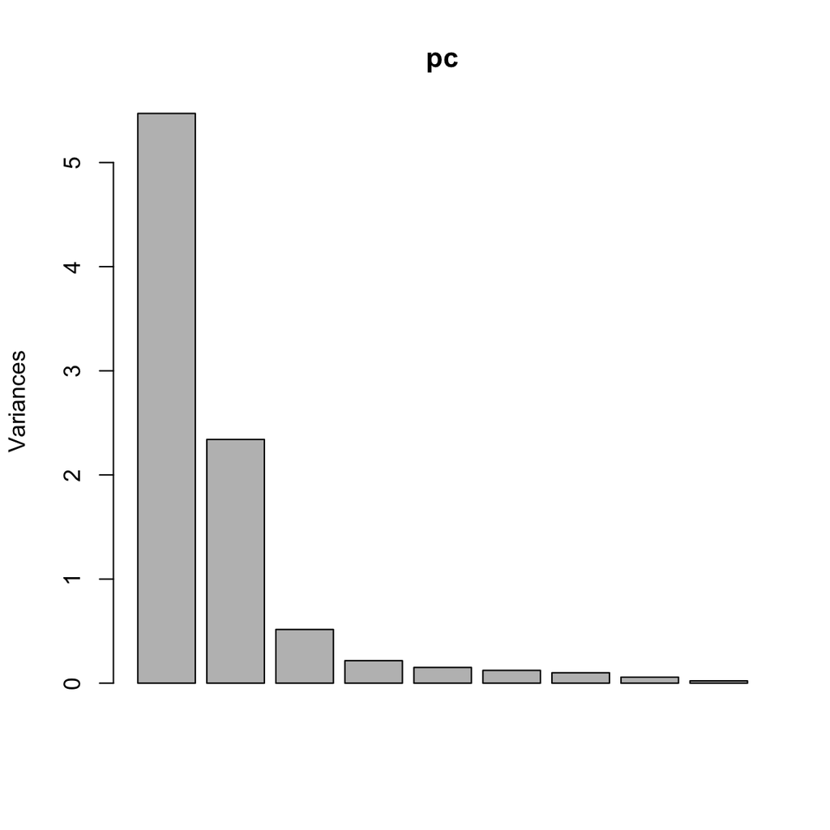

```r
# Conducting a principal components/factor analysis

# Load data
# ?mtcars
data(mtcars)
mtcars[1:5, ]
mtcars1 <- mtcars[, c(1:4, 6:7, 9:11)]  # Select variables
mtcars1[1:5, ]

# ========= Principle components model using default method
# If using entire data frame:
pc <- prcomp(mtcars1,
             center = TRUE,  # Centers means to 0 (optional)
             scale = TRUE)  # Sets unit variance (helpful)

# Or specify variables:
# pc <- prcomp(~ mpg + cyl + disp + hp + wt + qsec + am +
#                gear + carb, data = mtcars, scale = TRUE)

# ?prcomp  # Generally preferred
# ?princomp  # Very slightly different method, similar to S

# Get summary stats
summary(pc)

# Screeplot
plot(pc)
```

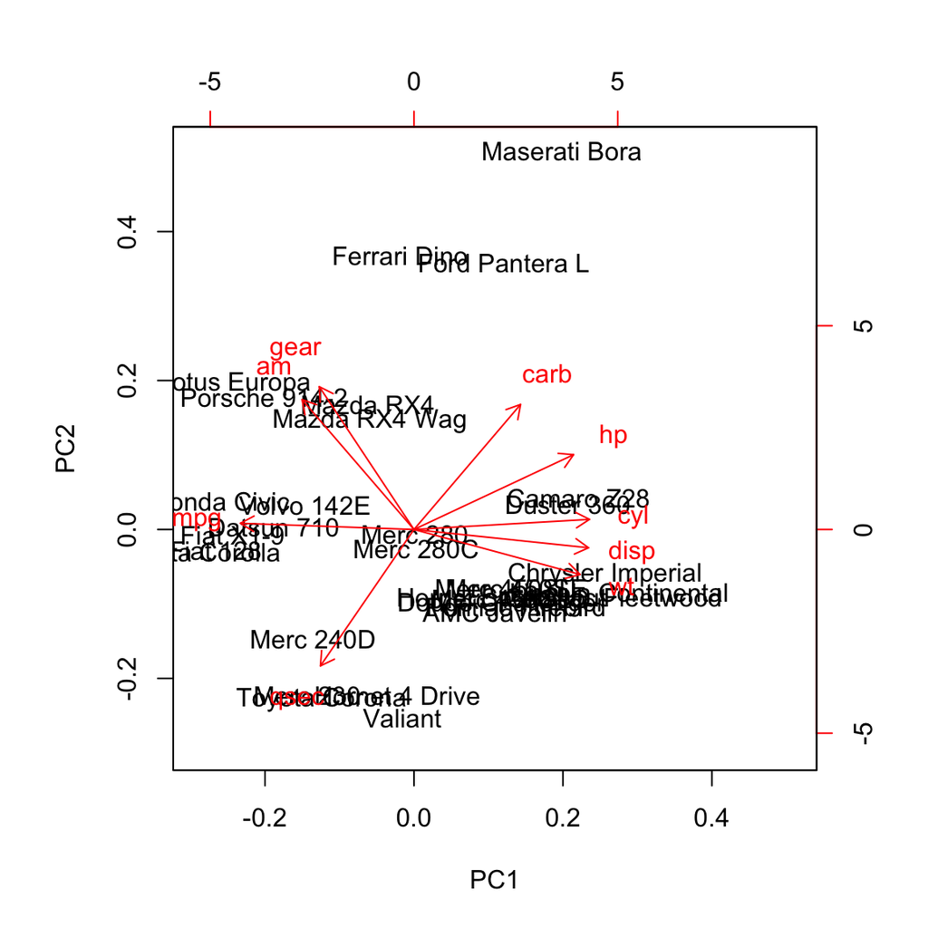

```r
# Get standard deviations and how variables load on PCs
pc

# See how cases load on PCs
predict(pc)

# Biplot
biplot(pc)
```

```r
# =========== Factor Analysis
# Varimax rotation by default
# Gives chi square test that number of factors
# is sufficient to match data (want p > .05).
# Also gives uniqueness values for variables,
# variable loadings on factors, and variance
# statistics.
factanal(mtcars1, 1)
factanal(mtcars1, 2)
factanal(mtcars1, 3)
factanal(mtcars1, 4)  # First w/p > .05
```

[output not shown]

### RESOURCES

- http://www.sthda.com/english/wiki/one-way-anova-test-in-r#what-is-one-way-anova-test
- http://www.sthda.com/english/wiki/correlation-test-between-two-variables-in-r
- http://www.sthda.com/english/wiki/correlation-matrix-a-quick-start-guide-to-analyze-format-and-visualize-a-correlation-matrix-using-r-software
- https://yutannihilation.github.io/allYourFigureAreBelongToUs/ggally/ggcorr/
- https://www.linkedin.com/learning/r-statistics-essential-training/computing-a-bivariate-regression (Linkedin Premium)
- https://thomasmock.netlify.com/post/a-gentle-guide-to-tidy-statistics-in-r/